# Analysis

Kevin Glock

11 9 2019

### Aim

### Theory

### Methodology

## Einwanderungsrate

- Korreltationstests: Einwanderungsrate und absolute/relative Häufigkeiten relevanter Diskursbegriffe im Diktonär
- absolute Einwanderungsrate war zwischen 1991 und 1995 über 1 Million sank dann und stieg nach 2012 erneut über eine Million (Statista 2019).

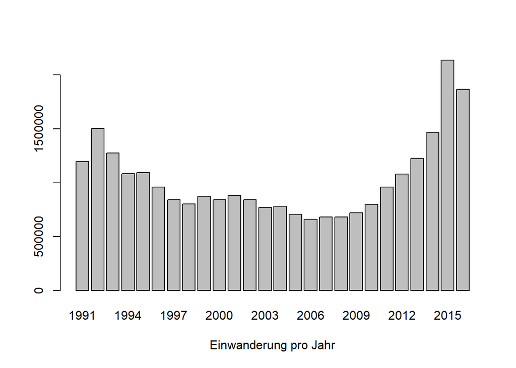

## Häufigkeiten

- Häufigkeiten der Flektionen der Lemmata “doppelt” und “Staatsbürger” und ihrer verschidenen Komposita zeigen grob approximierende Zeitverlaufskurven zur absoluten Einwanderungsrate.

## Häufigkeiten "[Ss]taatsbürger.*"

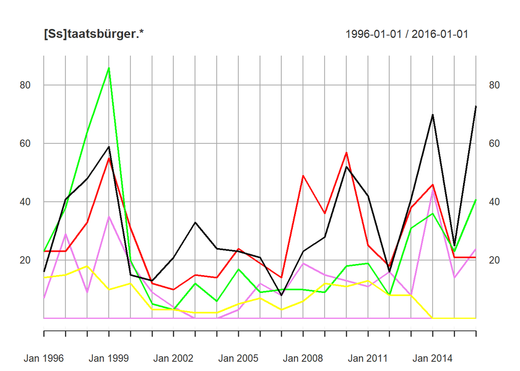

## Häufigkeiten “[Dd]oppelt.*" "[Ss]taatsbürger.*”’ , ’“[Dd]oppelstaatsbürg.*"‘,’"[Mm]ehrstaat.*”

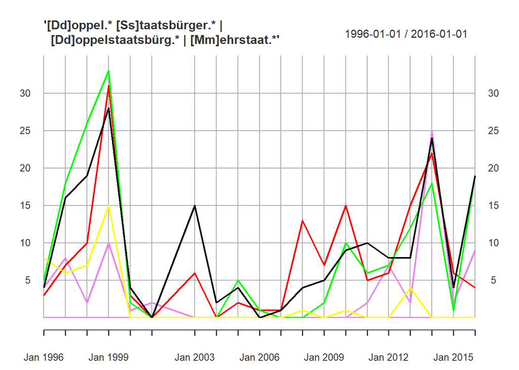

## Häufigkeiten "[Aa]ussied.*"

- Betrachten wir dabei unterschiedliche Hauptgruppen von Einwanderern (hier: Aussiedler und Asylsuchende) zeigt sich, Ende des 20. Jahrhunderts wurde vornehmlich über Aussiedler debattiert und ab den 2005er Jahren vermehrt über Asylsuchende.
- Hier besteht ein theoretisch interessanter Unterschied der Herkunft. Waren es Ende der 90er vornehmlich ethnische Deutsche (autochthone Migranten), die permant migrieren und wenige EU-Migranten, sind es nach 2005 vornhemlich allochthone Migranten aus dem Nahen Osten und Afrika, die im Diskurs scheinbar temporär migrieren und zudem steigende Zahlen an EU-Migranten.
- Hieraus leitet sich ein most similar cases design ab, das bei der Betrachtung von Unterschieden berücksichtigt wird

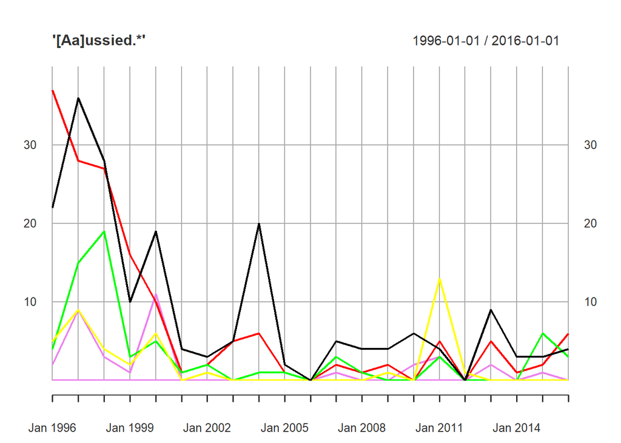

## Häufigkeiten "[Aa]syl.*"

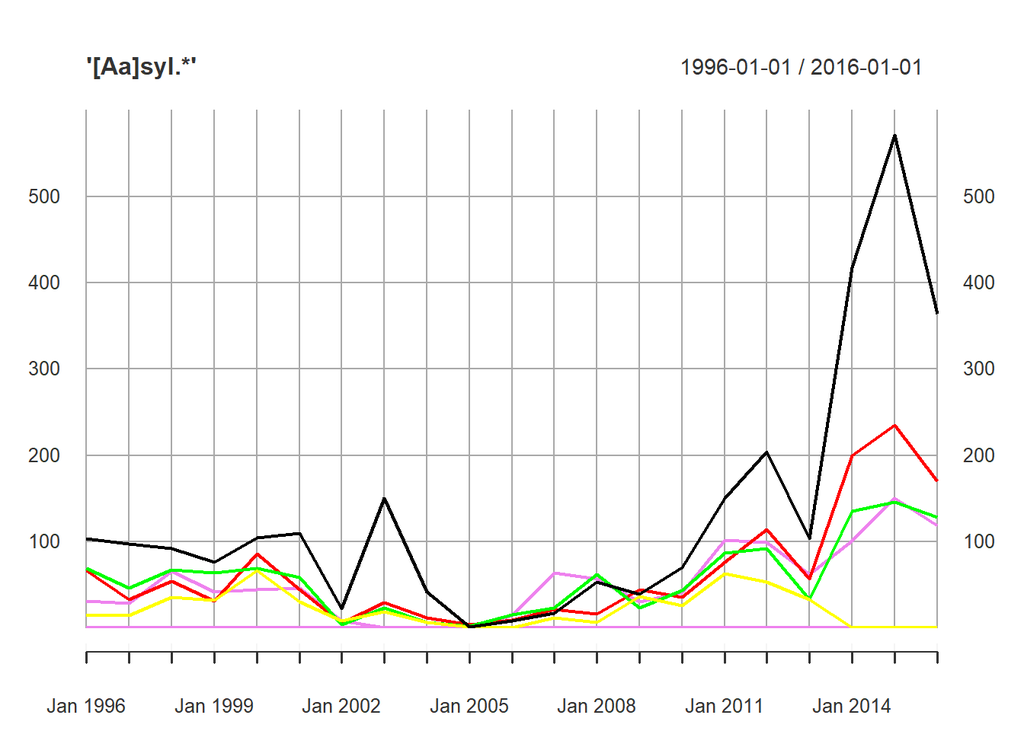

## Statistische Analyse

- Statistische Analyse: der Kookkurenzen der Diktionärsbegriffe (nach POS-tagging) nach Fraktionen (ll-ratio test)

## Kookkurrenzen Staatsbürgerschaft

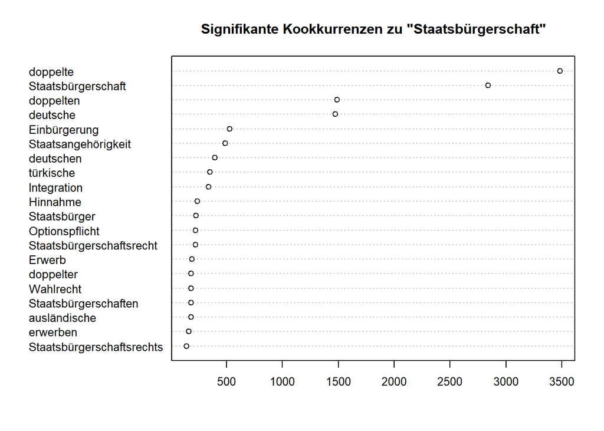

## Kookkurrenzen Optionspflicht

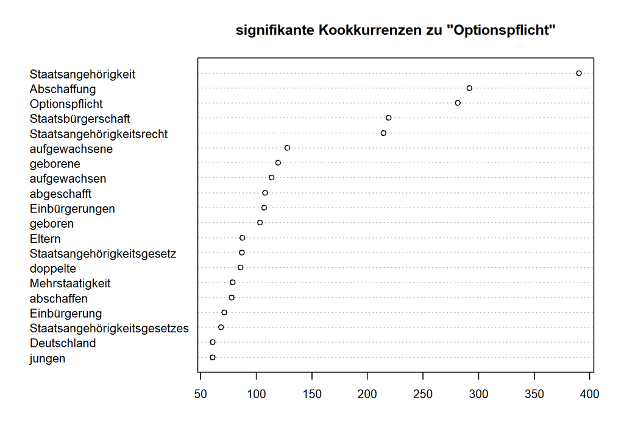

## Patitionen (Supkorpora)

- Es wird je eine Partition (Subkorpus) für die Fraktionen gebildet um diese vergleichbar zu machen
- Gemeinsam auftretende Begriffe können so zwischen den Gruppen verglichen werden

## Klassifikation

- Ziel: Klassifikation der sprachlichen Kontextualisierungen (identitär: national/transnational; universalistisch: humanitarisitsch; utilitaristisch: ökonomisch/ sozial) nach Part-Of-Speech und Fraktionen durch Subset-Methode; Auswertung: Divergenzen und Konvergenzen und Erklärung des Wandels über die Zeit durch Immigrationsrate und singuläre Kontextfaktoren (Islamkonferenz etc.)

### Literature